# QA NLI Scores - IAS (complete_bm)

Published

September 18, 2026

# IAS – granularity: complete_bm – nli_config: bge_m3_zeroshot_complete_bm

## Methodology

This report is a **QA check on Phase 1 (zero-shot NLI) scoring, not a scoring result in its own right** — it lets each claim’s scored citing works be spot-checked by eye (title, abstract, DOI, label, confidence, and the underlying class probabilities), and shows the overall SUPPORTS/REFUTES/NOT_ENOUGH_INFO x confidence distribution. It covers **Phase 1 only** — see `QA_LLM_Verification_Report.qmd` for the equivalent Phase 2 (LLM verification) QA report. See `TD_BM_NLI_approach.qmd` for the full NLI approach and `TD_NLI_LLM_two_phase.qmd` for how Phase 2 builds on this.

```r
if (isTRUE(x$empty)) {
  cat("No scored data available yet for this assessment/granularity/config combination — Phase 1 hasn't produced output here.\n\n")
  knitr::knit_exit()
}
```

```r
cat(sprintf(
  "- **%s** scored (claim, citing work) pairs in total\n",
  format(x$n_total, big.mark = ",")
))
```

- **355,300** scored (claim, citing work) pairs in total

```r
cat(sprintf(
  "- The table below shows up to **%d** highest-confidence rows per claim (**%s** rows shown here, out of the %s total) — every claim's own true row count is carried in the `n_total_claim` column so no truncation is silent; use the filters or the confusion matrix above for the full picture\n",
  x$per_claim_cap, format(x$n_shown, big.mark = ","), format(x$n_total, big.mark = ",")
))
```

- The table below shows up to **50** highest-confidence rows per claim (**4,900** rows shown here, out of the 355,300 total) — every claim’s own true row count is carried in the `n_total_claim` column so no truncation is silent; use the filters or the confusion matrix above for the full picture

## Label x confidence matrix

REFUTES/SUPPORTS/NOT_ENOUGH_INFO counts across confidence deciles, computed on the **full** scored dataset (not the capped table below).

```r
knitr::kable(x$matrix)
```

| label | 0.3-0.4 | 0.4-0.5 | 0.5-0.6 | 0.6-0.7 | 0.7-0.8 | 0.8-0.9 | 0.9-1.0 |
| --- | --- | --- | --- | --- | --- | --- | --- |
| SUPPORTS | 10849 | 41063 | 41402 | 33598 | 36178 | 36873 | 8876 |
| NOT_ENOUGH_INFO | 9723 | 33859 | 33306 | 25624 | 14608 | 3563 | 71 |
| REFUTES | 7919 | 11599 | 3362 | 2653 | 158 | 16 | 0 |

## Class probability distribution (ternary)

Since `p_supports + p_refutes + p_nei = 1` always, every row’s three class probabilities live on a 2D triangular surface rather than filling a 3D volume — this is the standard way to show exactly that kind of 3-part composition losslessly in 2D. Each corner is 100% one label; a point’s position encodes all three probabilities at once, and its color is the local **density** of scored pairs at that combination (log-scaled so structure is visible everywhere, not just at the tallest peaks). The three solid, coloured lines are the actual decision boundaries — where the winning label flips from one to another — running from the centroid out to each edge’s midpoint; each corner’s percentage is the real share of rows that label actually won.

The black dashed triangle is the **certain/uncertain boundary**: `label` is always the argmax of the three probabilities (which line above a point falls on decides that), but `confidence` — the *winning* probability — is a separate question, and a row is `uncertain` whenever `confidence` is below this granularity’s own `uncertain_threshold` (shown in the legend). Points inside the dashed triangle are `uncertain` regardless of which label technically won there; only the three small corners beyond it are `certain`. A label can be assigned with real confidence right up against this line while still counting as uncertain — the two are independent judgements, not the same thing read two ways.

When available, small white markers overlay the actual **key papers** — the seed/reference works IPBES cites as evidence for a BM, scored against that same BM’s claim (averaged across whatever claims exist under that BM — we don’t yet have claim-level evidence-to-paper mapping, only BM-level) — as a QA sanity check: a key paper *is* the evidence a BM was written from, so it should overwhelmingly land in the SUPPORTS region; if it doesn’t, that’s worth investigating, not a normal finding. Each corner’s bracketed percentage is the key papers’ own share for that label, next to the full-corpus share, so the two can be compared directly, followed by the p-value from a two-proportion test (key-paper share vs. full-corpus share for that corner) — a small p-value means the key-paper share is genuinely different from the full-corpus one, not just sampling noise from the much smaller key-paper count. This overlay comes from a separate scoring pass (`nli_scores_keypaper_evidence`) that now runs automatically alongside the main citing-works scoring — it’s absent here only on a cold first build, before that chain has produced anything yet.

```r
if (length(ternary_path)) {
  cat(sprintf('<img src="%s" style="max-width:100%%;"><br><br>\n\n', xfun::base64_uri(ternary_path)))
}
```

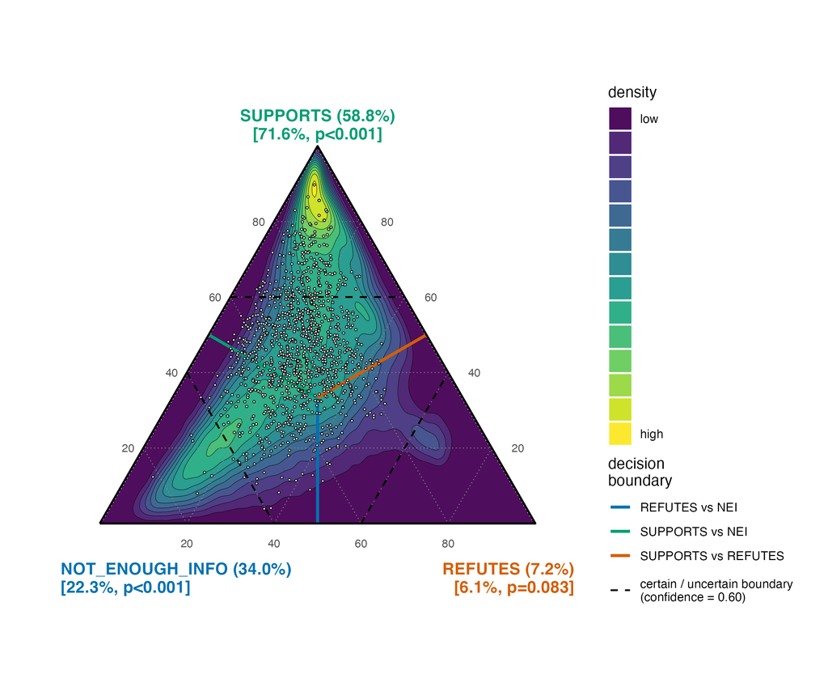

```r
if (!is.null(x$keypaper_summary)) {
  r <- x$keypaper_summary
  cat(sprintf(
    "**Key paper validation:** of **%d** key papers, **%.1f%%** landed in SUPPORTS\n\n",
    r$n, r$pct_supports
  ))
}
```

**Key paper validation:** of **1611** key papers, **71.6%** landed in SUPPORTS

## Claims and scores

Use the filter row below the header to narrow by KM, BM, claim, or label.

```r
x$widget
```

| km | bm | claim_id | claim | work | title | abstract | label | confidence | p_supports | p_refutes | p_nei | n_total_claim |
| --- | --- | --- | --- | --- | --- | --- | --- | --- | --- | --- | --- | --- |
| KM-A1 | A1 | bm_description-01 | Alien species (plants, animals, fungi and microorganisms, including pathogens) are being introduced globally at an unprecedented rate; currently, approximately 200 new alien species are recorded every… | 10.1111/1744-7917.70274 | Co‐invasion of multiple invasive ants exacerbates the impacts on native ant communities | The structure and function of native ant communities are increasingly threatened by the growing number of biological invaders spread around the world. Although the detrimental impacts of single-specie… | SUPPORTS | 0.908 | 0.908 | 0.04 | 0.052 | 7189 |
| KM-A1 | A1 | bm_description-01 | Alien species (plants, animals, fungi and microorganisms, including pathogens) are being introduced globally at an unprecedented rate; currently, approximately 200 new alien species are recorded every… | 10.3157/061.146.0308 | A Remarkable Addition to the Native Scolytine Fauna of the Ecologically Devastated Hawaiian Island of Lāna‘i and New Island Records for Five Exotic Bark and Ambrosia Beetles (Coleoptera: Curculionidae… | A survey for scolytine bark and ambrosia beetles undertaken on the entomologically understudied and ecologically devastated Hawaiian island of Lāna‘i, revealed the remarkable presence there of Xylebor… | SUPPORTS | 0.819 | 0.819 | 0.059 | 0.122 | 7189 |
| KM-A1 | A1 | bm_description-01 | Alien species (plants, animals, fungi and microorganisms, including pathogens) are being introduced globally at an unprecedented rate; currently, approximately 200 new alien species are recorded every… | 10.1038/s42003-018-0191-7 | Elevated atmospheric CO2 promoted speciation in mosquitoes (Diptera, Culicidae) | Abstract Mosquitoes are of great medical significance as vectors of deadly diseases. Despite this, little is known about their evolutionary history or how their present day diversity has been shaped. … | SUPPORTS | 0.811 | 0.811 | 0.071 | 0.118 | 7189 |
| KM-A1 | A1 | bm_description-01 | Alien species (plants, animals, fungi and microorganisms, including pathogens) are being introduced globally at an unprecedented rate; currently, approximately 200 new alien species are recorded every… | 10.1093/oso/9780198783398.003.0014 | Global climate change increases the need for genetic management | Abstract Adverse genetic impacts on fragmented populations are expected to accelerate under global climate change. Many populations and species may not be able to adapt in situ, or move unassisted to … | SUPPORTS | 0.807 | 0.807 | 0.071 | 0.122 | 7189 |
| KM-A1 | A1 | bm_description-01 | Alien species (plants, animals, fungi and microorganisms, including pathogens) are being introduced globally at an unprecedented rate; currently, approximately 200 new alien species are recorded every… | 10.1016/j.pecon.2020.10.002 | Human carnivory as a major driver of vertebrate extinction | Although a considerable part of the anthropogenic impacts on other species has been caused by our habit of eating other animals, little attention has been given to understanding and quantifying how hu… | SUPPORTS | 0.8 | 0.8 | 0.086 | 0.115 | 7189 |
| KM-A1 | A1 | bm_description-01 | Alien species (plants, animals, fungi and microorganisms, including pathogens) are being introduced globally at an unprecedented rate; currently, approximately 200 new alien species are recorded every… | 10.3390/zoonoticdis5010005 | Holistic Approaches to Zoonoses: Integrating Public Health, Policy, and One Health in a Dynamic Global Context | Zoonotic diseases pose a significant global health threat, driven by factors such as globalization, climate change, urbanization, antimicrobial resistance (AMR), and intensified human–animal interacti… | SUPPORTS | 0.78 | 0.78 | 0.059 | 0.161 | 7189 |
| KM-A1 | A1 | bm_description-01 | Alien species (plants, animals, fungi and microorganisms, including pathogens) are being introduced globally at an unprecedented rate; currently, approximately 200 new alien species are recorded every… | 10.1016/j.gecco.2025.e03579 | Human activity positively associated with the risk of spread of the giant African snail (Lissachatina fulica) recently reported in central and northern China | The highly invasive giant African snail ( Lissachatina fulica ), one of the most damaging mollusk species in the world, damages over 500 plants and threatens conservation of endemic snails. It widely … | SUPPORTS | 0.771 | 0.771 | 0.095 | 0.134 | 7189 |
| KM-A1 | A1 | bm_description-01 | Alien species (plants, animals, fungi and microorganisms, including pathogens) are being introduced globally at an unprecedented rate; currently, approximately 200 new alien species are recorded every… | 10.25260/ea.17.27.2.0.478 | La leña como vía para la introducción de insectos. ¿Cuáles son los riesgos de las invasiones de hormigas en la Patagonia? | Firewood can act as a long-distance dispersal vector for wood-infesting insects both within and among countries. Recently, we detected the alien carpenter ant Camponotus mus in firewood transported fr… | SUPPORTS | 0.767 | 0.767 | 0.104 | 0.128 | 7189 |
| KM-A1 | A1 | bm_description-01 | Alien species (plants, animals, fungi and microorganisms, including pathogens) are being introduced globally at an unprecedented rate; currently, approximately 200 new alien species are recorded every… | 10.1016/j.aquabot.2019.103166 | Hybridization with natives augments the threats of introduced species in Sonneratia mangroves |  | SUPPORTS | 0.766 | 0.766 | 0.091 | 0.143 | 7189 |
| KM-A1 | A1 | bm_description-01 | Alien species (plants, animals, fungi and microorganisms, including pathogens) are being introduced globally at an unprecedented rate; currently, approximately 200 new alien species are recorded every… | 10.1111/tbed.14738 | Evidence for overwintering and autochthonous transmission of Usutu virus to wild birds following its redetection in the United Kingdom | Usutu virus (USUV) is an emerging zoonotic arbovirus in Europe, where it primarily impacts Eurasian blackbirds (Turdus merula). For mosquito-borne viruses to persist in temperate areas, transovarial t… | SUPPORTS | 0.763 | 0.763 | 0.092 | 0.146 | 7189 |

[output cut: 4890 more lines]